# Lab 3: Topic Analysis

## 4. Plot the top terms in each topic and the distribution of topics across a sample of the documents (constrained by what looks good in the plot).

### Steps:

#### a) Examine at our results.

#### c) Extract the top words releated to the topics

#### d) Visualize the results in a plot

```r
#Calculating the posterior distribution of the topic model
tmResult <- posterior(topicModel_k5)

# Prints the top 5 terms for each of the topics in the topicModel_k5 model.
terms(topicModel_k5, 5)
```

```
##      Topic 1       Topic 2         Topic 3        Topic 4      Topic 5
## [1,] "carbon"      "research"      "mangrove"     "carbon"     "marine"
## [2,] "will"        "news"          "mangroves"    "blue"       "conservation"
## [3,] "development" "change"        "forests"      "ecosystems" "coastal"
## [4,] "project"     "science"       "conservation" "can"        "blue"
## [5,] "projects"    "environmental" "area"         "emissions"  "economy"
```

```r
# Extracting the matrix of document-topic probabilities from tmResult.
# Theta shows how likely that document is to be associated with each of the topics in the model. The theta matrix can be used to identify the most relevant topics for a particular document.
theta <- tmResult$topics

# Extracting the matrix of topic-term probabilities from tmResult.
# Beta shows how likely each word in the vocabulary is to be associated with that topic. Is the relationship between the words in the vocabulary and the topics in the model.
beta <- tmResult$terms

# Extracting the column names (i.e., the vocabulary) of the beta matrix and storing it in vocab.
vocab <- (colnames(beta))
```

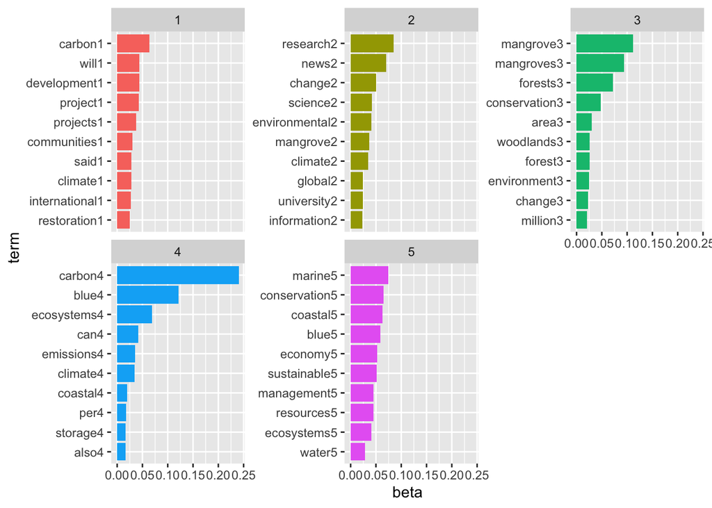

```r
# b) Creating a "tidy" data frame from the topic-term matrix (also known as the "beta" matrix)
main_five_topics <- tidy(topicModel_k5, matrix = "beta")

# c) Extracting the top 10 terms for each of the five topics in a topic model and arranging them in a tidy data frame.
top_blue_carbon_terms <- main_five_topics %>%
  group_by(topic) %>%
  top_n(10, beta) %>%
  ungroup() %>%
  arrange(topic, -beta)

# d) Visualize the most significant terms for each topic in a blue carbon analysis
top_blue_carbon_terms %>%
  mutate(term = reorder_within(term, beta, topic, sep = "")) %>%
  ggplot(aes(term, beta, fill = factor(topic))) +
  geom_col(show.legend = FALSE) +
  facet_wrap(~ topic, scales = "free_y") +
  scale_x_reordered()+
  coord_flip()
```

The highest beta values can be interpreted as the most salient words for a given topic, as they are the words that are most strongly associated with that topic in the corpus. Conversely, the lowest beta values can be interpreted as words that are not very relevant to the topic, as they are not strongly associated with it.

## 5. Take a stab at interpreting the resulting topics. What are the key themes discussed in the articles in your data base? Use the words, use what you know about the articles, and do an interpretation of what they mean.

### Steps:

#### a) Assign the names to the topics

#### b) Wrangle the data to plot

To help us identify the topics we’re working with, we can assign names to them.

```r
# a)
topic_words <- terms(topicModel_k5, 5)
topic_names <- apply(topic_words, 2, paste, collapse = " ")
```

We can explore the theta matrix, which contains the distribution of each topic over each document.

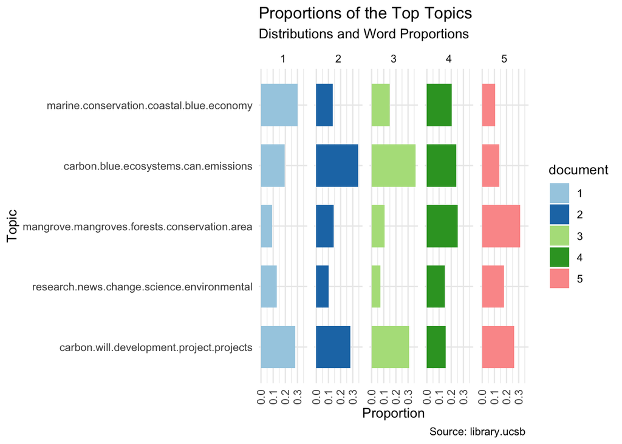

```r
# b) Reshape the data in a format that can be visualized using ggplot

# Create a vector of example document IDs from 1 to 5, and get the length of the vector
example_ids <- c(1:5)

# Extract the topic proportions from the theta matrix for the example documents
n <- length(example_ids)

# Assign the topic names as column names to the example_props matrix
example_props <- theta[example_ids,]

# Reassign the names to the matrix
colnames(example_props) <- topic_names


# Use the melt function to convert the matrix to a long format, and create additional columns.
viz_df <- melt(cbind(data.frame(example_props),
                     document = factor(1:n),
                     variable.name = "topic",
                     id.vars = "document"))
# c) Create a bar chart with ggplot, using the reshaped data
my_palette <- brewer.pal(5, "Paired")

ggplot(data = viz_df, aes(x = variable,
                          y = value,
                          fill = document)) +
  geom_bar(stat="identity", width = 0.7) +
  scale_fill_manual(values = my_palette) +
  labs(x = "Topic",
       y = "Proportion",
       title = "Proportions of the Top Topics",
       subtitle = "Distributions and Word Proportions",
       caption = "Source: library.ucsb ") +
  theme_minimal() +
  theme(axis.text.x = element_text(angle = 90, vjust = 0.5, hjust=1)) +
    coord_flip() +
  facet_wrap(~ document, ncol = n)
```

```r
library(LDAvis) #visualization
library("tsne") #matrix decomposition
svd_tsne <- function(x) tsne(svd(x)$u)
json <- createJSON(
  phi = tmResult$terms,
  theta = tmResult$topics,
  doc.length = rowSums(matrix_trimmed),
  vocab = colnames(matrix_trimmed),
  term.frequency = colSums(matrix_trimmed),
  mds.method = svd_tsne,
  plot.opts = list(xlab="", ylab="")
)
```

[output not shown]

[output not shown]

[output not shown]

[output not shown]

[output not shown]

[output not shown]

[output not shown]

[output not shown]

[output not shown]

[output not shown]

[output not shown]

```r
serVis(json)
```